# Advanced EDA & Patterns

## Where we left off

Day 5 gave you the **tools**: histograms, scatter plots, box plots, faceting, smoothing.

Today is about the **questions** those tools answer:

- Which variables move together?
- Which observations don’t belong?
- What do you do when a distribution is badly skewed?

Same `ggplot2` skeleton throughout — we’re adding judgment, not syntax.

## Today’s dataset: `Credit`

400 credit card customers from ISLR2 — `glimpse()` shows what you have:

```r
data(Credit)
glimpse(Credit)
```

```
## Rows: 400
## Columns: 11
## $ Income    <dbl> 14.891, 106.025, 104.593, 148.924, 55.882, 80.180, 20.996, 7…
## $ Limit     <dbl> 3606, 6645, 7075, 9504, 4897, 8047, 3388, 7114, 3300, 6819, …
## $ Rating    <dbl> 283, 483, 514, 681, 357, 569, 259, 512, 266, 491, 589, 138, …
## $ Cards     <dbl> 2, 3, 4, 3, 2, 4, 2, 2, 5, 3, 4, 3, 1, 1, 2, 3, 3, 3, 1, 2, …
## $ Age       <dbl> 34, 82, 71, 36, 68, 77, 37, 87, 66, 41, 30, 64, 57, 49, 75, …
## $ Education <dbl> 11, 15, 11, 11, 16, 10, 12, 9, 13, 19, 14, 16, 7, 9, 13, 15,…
## $ Own       <fct> No, Yes, No, Yes, No, No, Yes, No, Yes, Yes, No, No, Yes, No…
## $ Student   <fct> No, Yes, No, No, No, No, No, No, No, Yes, No, No, No, No, No…
## $ Married   <fct> Yes, Yes, No, No, Yes, No, No, No, No, Yes, Yes, No, Yes, Ye…
## $ Region    <fct> South, West, West, West, South, South, East, West, South, Ea…
## $ Balance   <dbl> 333, 903, 580, 964, 331, 1151, 203, 872, 279, 1350, 1407, 0,…
```

`Balance` (in $) is our outcome; `Income` is in **$1,000s**. The data is *simulated* — fine for learning, no claim about real borrowers.

## Recap: the EDA loop

1. **Ask** a question about the data.
2. **Visualize / transform / model** to answer it.
3. Use what you learn to **ask a sharper question**.

Two questions do most of the work (R4DS Ch 7):

- **Variation** — how does one variable behave on its own?
- **Covariation** — how do two variables behave *together*?

## The question: who carries a big balance?

First guess: people who earn more.

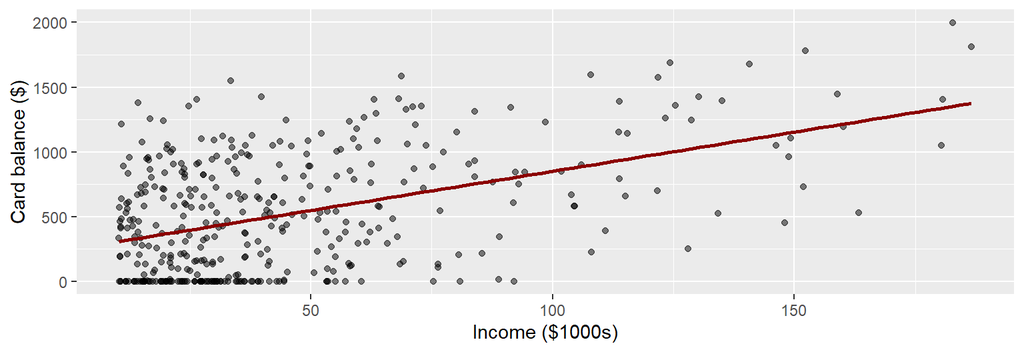

Positive, but loose. Look at customers earning **$40-60k**: their balances run from **$0 to $1,246**. Income clearly isn’t the whole story.

**A clue:** students earn about the same as non-students (**$47k** vs **$45k**) but carry nearly **double** the balance (**$877** vs **$480**). Worth splitting on.

## Facet + smooth: does it hold for both groups?

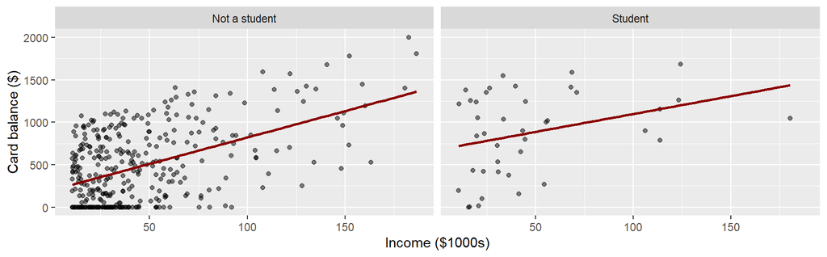

```r
ggplot(Credit, aes(x = Income, y = Balance)) +
  geom_point(alpha = 0.5) +
  geom_smooth(method = "lm", se = FALSE, color = "darkred") +
  facet_wrap(~ Student, labeller = labeller(          # else strips read "No"/"Yes"
    Student = c("No" = "Not a student", "Yes" = "Student"))) +
  labs(x = "Income ($1000s)", y = "Card balance ($)")
```

Both panels slope up, but students sit **higher** — roughly **$400 more at the same income** (the gap narrows from ~$420 at $30k to ~$360 at $60k).

## Correlation matrices

**The question:** which of our seven numeric variables are worth putting in a model, and is any pair telling us the same thing twice? One scatter plot at a time would take 21 plots; a **correlation matrix** does it in one.

```r
cor_matrix <- Credit %>%
  select(Income, Limit, Rating, Balance, Cards, Age, Education) %>%   # correlated
  cor()                                                              # ones first
round(cor_matrix, 2)
```

```
##           Income Limit Rating Balance Cards  Age Education
## Income      1.00  0.79   0.79    0.46 -0.02 0.18     -0.03
## Limit       0.79  1.00   1.00    0.86  0.01 0.10     -0.02
## Rating      0.79  1.00   1.00    0.86  0.05 0.10     -0.03
## Balance     0.46  0.86   0.86    1.00  0.09 0.00     -0.01
## Cards      -0.02  0.01   0.05    0.09  1.00 0.04     -0.05
## Age         0.18  0.10   0.10    0.00  0.04 1.00      0.00
## Education  -0.03 -0.02  -0.03   -0.01 -0.05 0.00      1.00
```

Forty-nine numbers is more than anyone can scan. The same matrix, as a picture:

## The same numbers, as a heatmap

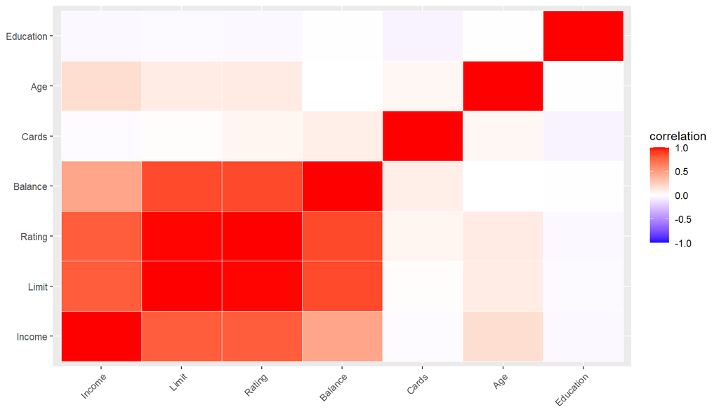

## Reading it

Seven variables sort into **one dark block and three loners.** Back to our two questions:

- **Which variables matter?**
  - `Balance` tracks `Limit` and `Rating` at **0.86**, `Income` at **0.46**
  - `Cards`, `Age` and `Education` track nothing — 30 of the 49 tiles sit below |r| = 0.2
- **Anything redundant?**
  - `Limit` and `Rating` correlate at **0.997** — the same variable twice, so keep one
- **So what do we actually do?**
  - Model `Balance` with `Income` and **one** of `Limit` / `Rating`
  - Leave `Cards`, `Age` and `Education` out until something else argues for them
- **Careful:**
  - Correlation catches only *linear* association — so plot as well
  - Weak pairwise correlation isn’t useless; a variable can still matter *in combination*

## Building the heatmap

```r
cor_long <- as.data.frame(cor_matrix) %>%
  mutate(var1 = rownames(cor_matrix)) %>%
  pivot_longer(-var1, names_to = "var2", values_to = "correlation") %>%
  mutate(var1 = factor(var1, levels = colnames(cor_matrix)),   # keep the table's
         var2 = factor(var2, levels = colnames(cor_matrix)))   # order, not A-Z

ggplot(cor_long, aes(x = var1, y = var2, fill = correlation)) +
  geom_tile(color = "white") +
  scale_fill_gradient2(low = "blue", mid = "white", high = "red",
                       midpoint = 0, limits = c(-1, 1)) +
  labs(x = NULL, y = NULL) +
  theme(axis.text.x = element_text(angle = 45, hjust = 1))
```

`pivot_longer()` (Day 4) turns the 7 x 7 grid into 49 rows — one per tile, and `factor()` holds the axes in the matrix’s own order (without it ggplot sorts them A–Z and the tiles stop lining up with the table). The diverging palette pins **white at zero**, so sign reads at a glance — nothing in `Credit` is negative enough to show blue, but the activity’s data is.

## The question: who doesn’t fit?

The issuer sets credit limits from this data. A rule fitted to the *typical* customer can badly misprice the unusual ones.

So: which customers are unlike the rest — **and why?** An outlier could be

- a **data error** — a typo, a sentinel like -999, a unit mix-up
- a **rare event** that is entirely real
- the **most interesting observation** you have

You can’t tell which from the number alone. **Investigate before you delete.**

## Density plots

A smoothed histogram — good for spotting isolated bumps.

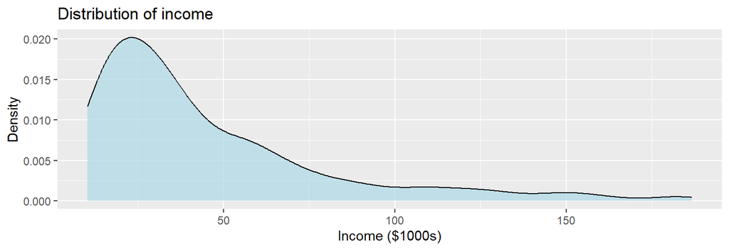

> That right tail: a few **unusual customers**, or simply the **shape** income has? Neither rule we’re about to meet can tell those apart.

## The IQR rule

The most common convention — flag anything outside \(Q1 - 1.5 \times IQR\) or \(Q3 + 1.5 \times IQR\):

```r
Q1 <- quantile(Credit$Income, 0.25); Q3 <- quantile(Credit$Income, 0.75)
IQR_val <- Q3 - Q1
outliers <- Credit %>%
  filter(Income < Q1 - 1.5 * IQR_val | Income > Q3 + 1.5 * IQR_val)

nrow(outliers)                                    # how many flagged
```

```
## [1] 29
```

```r
outliers %>% select(Income, Limit, Balance) %>% arrange(desc(Income)) %>% head(4)
```

```
##    Income Limit Balance
## 1 186.634 13414    1809
## 2 182.728 13913    1999
## 3 180.682 11966    1405
## 4 180.379  9310    1050
```

## Box plots draw the same rule

The whiskers *are* the 1.5 × IQR fences, and those dots are the same 29 rows.

**So every box plot you have ever drawn was already applying this rule.** Those dots are a convention being *drawn*, not errors being *found*.

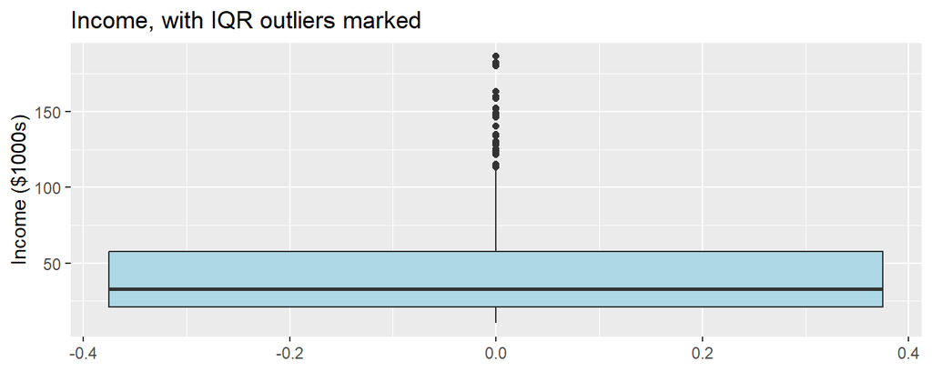

```r
ggplot(Credit, aes(y = Income)) +
  geom_boxplot(fill = "lightblue") +
  labs(title = "Income, with IQR outliers marked", y = "Income ($1000s)")
```

## The z-score rule

How many standard deviations from the mean? Flag \(|z| > 2\) (or 3).

```r
z_out <- Credit %>%
  mutate(income_z = as.numeric(scale(Income))) %>%
  filter(abs(income_z) > 2)

nrow(z_out)                                       # fewer than the IQR rule found
```

```
## [1] 24
```

```r
z_out %>% select(Income, income_z) %>% arrange(desc(income_z)) %>% head(5)
```

```
##    Income income_z
## 1 186.634 4.012428
## 2 182.728 3.901602
## 3 180.682 3.843550
## 4 180.379 3.834953
## 5 163.329 3.351186
```

## IQR vs. z-score

|  | IQR rule | z-score rule |
| --- | --- | --- |
| Built from | quartiles (median-based) | mean and SD |
| Skewed data | **robust** | struggles — outliers inflate the very SD they’re measured against |
| Reports | in / out | *how far* out |
| Units | the variable’s own | **none** — `z = 2` means the same for income and for age |
| Also used for | — | **standardizing** variables — several models we meet later this term need it |

Same data, same variable: IQR flagged **29**, z-score flagged **24** (a few extreme points help hide each other).

- **IQR to *detect*** — which points are worth a look, especially when the data is skewed.
- **z to *measure*** — *how* unusual a point is, on a scale that means the same thing for every variable.

## Skew, and what to do about it

Back to the tail. `Income` is right-skewed — most customers bunched left, a few stretching far right. A **log transform** pulls that tail in.

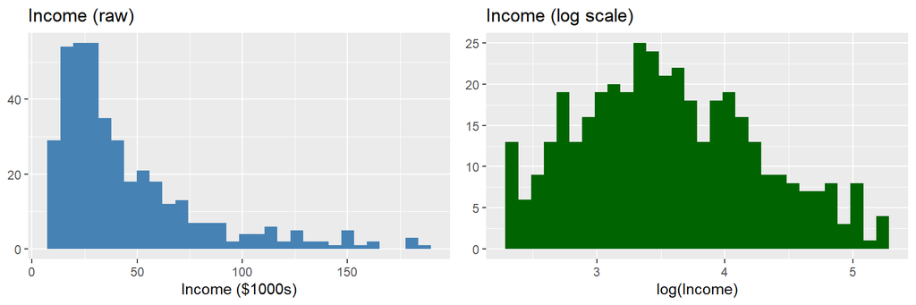

```r
raw <- ggplot(Credit, aes(x = Income)) + geom_histogram(bins = 30, fill = "steelblue") +
  labs(title = "Income (raw)", x = "Income ($1000s)", y = NULL)
logged <- ggplot(Credit, aes(x = log(Income))) + geom_histogram(bins = 30, fill = "darkgreen") +
  labs(title = "Income (log scale)", x = "log(Income)", y = NULL)
grid.arrange(raw, logged, ncol = 2)
```

## Why economists log things

- Makes skewed distributions roughly **symmetric**.
- Turns multiplicative relationships into additive ones.
- Coefficients read as **percent changes** — usually what we want.

**The cost:** the axis is no longer in dollars.

Miss the “log” in the label and you misread the whole plot. So label it.

## Conventions, not verdicts

One last thing the log bought us. Go back and re-run **both** outlier rules, this time on the logged variable:

```
##      variable IQR_rule z_rule_2sd
## 1      Income       29         24
## 2 log(Income)        0         14
```

- **The IQR rule drops from 29 flagged rows to zero.**
  - Same customers, same data — only the *scale* we measured on changed
  - There’s the answer to our question: it was the **shape**, not 29 unusual customers
- **What to do about it:**
  - Plot the distribution **before** you run either rule
  - If it’s skewed, log it first, *then* re-flag
  - Investigate whatever survives — never delete on a rule’s say-so

## Summary

- **Facet + smooth:** does the relationship change across groups?
- **Correlation matrix + heatmap:** every pairwise linear relationship at once — but linear only, so plot too.
- **Outliers:** IQR to *detect*, z to *measure* — neither is a verdict.
- **Log transforms:** tame skew, read as percent changes, label carefully.
- **Those last two are one idea:** “outlier” describes a point *relative to an assumed shape*. Fix the shape and 29 of ours became **zero**.
- **Why the issuer cares:** a rule fitted to the bulk predicts worst where the data is thinnest. Flagging outliers is about knowing which predictions to distrust — not about deleting rows. More on this when we reach regression.

## For the rest of class

- Work on the `day6_activity` — real World Happiness Report data
- Ask me questions if you run into issues